# An introduction to causal inference

Feb. 28, 2017

## The fundamental problem

## What is causal inference?

The typical problem of causal inference can be presented as follows.

Denote

- \(Y\) is an outcome of interest,
- \(A\) is a binary treatment variable, and
- \(W\) is a vector of observed covariates.

We are interested in learning the effect of \(A\) on \(Y\).

## Setup

Frameworks for causal inference:

- the potential outcomes framework,
- non-parametric structural equation models (NPSEM), and
- a few more

Let's focus on NPSEMs

## NPSEM

Assume we observe \(n\) copies of \(O=(W,A,Y)\). An NPSEM is a *generative* model, in which the data are assumed to be generated by a set of equations

\[ \begin{eqnarray} W & = & f_W(U_W)\\ A & = & f_A(W,U_A)\\ Y & = & f_Y(W,A,U_Y)\\ \end{eqnarray} \]

- \(U_W\), \(U_A\), and \(U_Y\) are *unobserved*, exogenous variables
- \(f_W\), \(f_A\), and \(f_Y\) are *unknown*, but fixed functions

## Counterfactuals

Causal effects are defined in terms of an *intervention* on the data generating mechanism. For example, what would be the effect of setting \(A=1\)?

In an NPSEM, variables under an intervention are called *counterfactuals*. In our example, we have two counterfactuals:

\[ \begin{eqnarray} Y_1 & = & f_Y(W,1,U_Y)\\ Y_0 & = & f_Y(W,0,U_Y) \end{eqnarray} \]

In the potential outcomes framework, \(Y_a:a=0,1\) is the primitive.

## Causal effects

Causal effects are often defined as contrasts between counterfactuals. For example:

- Average treatment effect:

\[E(Y_1) - E(Y_0)\]

- Risk ratio

\[\frac{E(Y_1)}{E(Y_0)}\]

The fundamental problem of causal inference is that countefactuals are not observed. So the question is, can we estimate the above quantities from data on \(O=(W,A,Y)\)? This is the problem of *identification*.

## Identification

## Identification

Under the assumption that

\[A \perp U_Y \mid W\]

We can show (math omitted but happy to show it)

\[E(Y_1) = E_W[E(Y | A=1, W)]\]

(Note: in a randomized trial \(A\) is independent of everything, that is why it is often considered the gold standard.)

Likewise

\[E(Y_0) = E_W[E(Y | A=0, W)]\]

## Identification

An NPSEM can be visually represented in a *directed acyclic graph* (DAG)

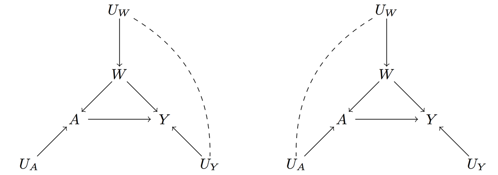

The above DAGs satisfy \(A \perp U_Y \mid W\).

This concludes the causal inference problem. All we have to do now is statistics to estimate

\[E(Y_1) = E_W[E(Y | A=1, W)]\]

## Estimation

## Let us first revise traditional estimators

When \(Y\) is binary, a common approach is to look at the coefficient of treatment in a logistic regression:

\[ \DeclareMathOperator{\logit}{logit} \logit P(Y=1\mid A=a, W=w) = \beta_0 + \beta_1a + \beta_2w \]

A very common mistake is to take \(\exp(\beta_1)\) and say ''this is the odds ratio adjusted for covariates''

## R illustration

We will use the WCGS dataset in the R epitools package. We focus on the effect of smoking on CHD.

```r
library(epitools)
library(dplyr)
library(tidyr)

data(wcgs)
y <- select(wcgs, chd69)[, 1]
a <- as.numeric(select(wcgs, ncigs0)[, 1] > 0)
w <- select(wcgs, age0, height0, weight0, dibpat0)
fit <- glm(y ~ ., data = data.frame(a = a, w),
           family = binomial(link = logit))
```

## R illustration

```r
exp(coef(fit)['a'])
```

```
##        a
## 1.981932
```

```r
mu1 <- predict(fit, newdata = data.frame(a = 1, w), type = 'response')
mu0 <- predict(fit, newdata = data.frame(a = 0, w), type = 'response')
or <- (mean(mu1) / (1 - mean(mu1))) / (mean(mu0) / (1 - mean(mu0)))
or
```

```
## [1] 1.937736
```

(Note: inspection of the OR equation reveals that we are implicitly imputing the counterfactual outcomes)

## Other parameters in logistic regression

We could also compute other contrasts, e.g.,

\[E[E(Y \mid A=1, W)] - E[E(Y\mid A=0, W)]\] by computing \(E(Y \mid A=1, W)]\) for all subjects, subtracting E(Y A=0, W)], and taking a sample average.

```r
mean(mu1) - mean(mu0)
```

```
## [1] 0.0489257
```

or the RR

```r
mean(mu1) / mean(mu0)
```

```
## [1] 1.837045
```

## Other problems with this approach

- If the model is wrong (which it most certainly is), then \(\beta_1\) has no clear interpretation.
- Assumes no \(A\times W\) interactions.
- Such interactions are often very important, indicating treatment effect modification (also called predictive power).
- In high dimensions (\(W\) contains many variables), there is absolutely no reason to believe the model is a good enough approximation.
- This can cause (potentially large) amounts of bias.

## Solution

The machine and statistical learning literature contain a wealth of methods to estimate conditional probabilities and expectations. A few examples:

- Regression trees (random forests, xgboost, cart, etc.)
- Support vector machines
- Multivariate adaptive regression splines
- Least square angle regression (\(L_1\) regularization)
- Neural networks, etc.

All of these can be used to estimate

\[E(Y \mid A=a, W=w)\text{ for } a = 0,1\]

## Solution

Once we train our learning algorithm, we can compute

\[ \begin{eqnarray} &\hat E(Y \mid A=1, W_i)\\ &\hat E(Y \mid A=0, W_i) \end{eqnarray} \]

For all subjects \(i\) in the sample, and the estimate of the ATE is

\[\frac{1}{n}\sum_{i=1}^n\hat E(Y \mid A=1, W_i) - \frac{1}{n}\sum_{i=1}^n\hat E(Y \mid A=0, W_i)\]

## R illustration

```r
library(SuperLearner)
lib <- c('SL.glm', 'SL.randomForest', 'SL.bayesglm',
         'SL.earth', 'SL.gam')
fitSL <- SuperLearner(Y = y , X = data.frame(a = a, w),
                      family = binomial(), SL.library = lib)
## ATE
mean(predict(fitSL, newdata = data.frame(a = 1, w))$pred[, 1] -
     predict(fitSL, newdata = data.frame(a = 0, w))$pred[, 1])
```

```
## [1] 0.04561105
```

## Problems with the SL estimator

We have no statistical inference available (p-values, confidence intervals, exact or asymptotic distributions).

## Propensity score

The *propensity score* is defined as:

\[P(A=1\mid W=w)\]

- This is just a conditional probability so it can (should?) be estimated using data-adaptive methods.
- Logistic regression can be used in a RCT: \[P(A=a\mid W=w) = \beta_0 + \beta_1w\text{ (we know $\beta_1=0$)}\]

## Inverse probability weighting

You can do the math to check that

\[E[E(Y\mid A=1, W)] = E\left[\frac{A}{P(A=1\mid W)} Y\right]\]

This teaches us that another possible estimator is the *inverse probability weighted estimator*

\[\frac{1}{n}\sum_{i=1}^n\frac{A_i}{\hat P(A=1\mid W_i)}Y_i\]

## R illustration

```r
fitSL <- SuperLearner(Y = a , X = w,
                      family = binomial(), SL.library = lib)

## Pscore
ps <- predict(fitSL)$pred[, 1]
## ATE
mean(a / ps * y) - mean((1 - a) / (1 - ps) * y)
```

```
## [1] 0.04858146
```

## Problems with the IPW estimator

If the propensity score is estimated with machine learning, We have no statistical inference available.

## Solution

There are (at least) two estimators that solve this problem:

- Augmented inverse probability weighting (AIPW)
- Targeted minimum loss based estimation (TMLE)

These estimators have nice properties (under some conditions):

- Doubly robust: consistent if either the propensity score or the outcome regression are consistently estimated
- Efficient (in the sense of a Cramer-Rao lower bound) if both are consistent
- Normal asymptotic distribution (can obtain approximate p-values and CIs)

## Further reading

- J. Pearl. "Causal inference in statistics: An overview." *Statistics Surveys* 3 (2009): 96-146.
- M. J. van der Laan and S. Rose. *Targeted learning: causal inference for observational and experimental data*. Springer, 2011.